# model2

2025-11-21

```r
library(MASS)
library(car)
credit_data <- read.csv("credit_card_data.csv")

set.seed(7)
train_index <- sample(1:nrow(credit_data), size = nrow(credit_data) * 0.7)
train_data <- credit_data[train_index, ]
test_data  <- credit_data[-train_index, ]

head(train_data) #923 rows
```

```
##      card reports      age income        share expenditure owner selfemp
## 476   yes       0 21.50000 2.3779 0.0179990800    35.16667    no      no
## 706   yes       0 23.41667 1.8600 0.2670521000   413.59750    no      no
## 218   yes       0 29.16667 2.5000 0.0767256000   159.59500    no      no
## 630   yes       0 24.08333 1.6200 0.0105080200    13.68583    no      no
## 1016   no       0 30.08333 3.1200 0.0003846154     0.00000    no      no
## 835   yes       1 36.33333 7.3500 0.0712285700   436.27500    no      no
##      dependents months majorcards active
## 476           0      7          0      5
## 706           0      3          1      4
## 218           0      7          1     21
## 630           0     12          0      4
## 1016          2     12          0      5
## 835           0     51          0     14
```

```r
# head(test_data) #396 rows
```

# **Step 1 — Fit Your First-Order Model (Individual Work)**

```r
model1 <- lm(expenditure ~ income + share + dependents + months + active, data = train_data)
summary(model1)
```

```
##
## Call:
## lm(formula = expenditure ~ income + share + dependents + months +
##     active, data = train_data)
##
## Residuals:
##     Min      1Q  Median      3Q     Max
## -512.80  -29.22    3.86   28.43 1072.21
##
## Coefficients:
##               Estimate Std. Error t value Pr(>|t|)
## (Intercept) -129.64194    8.34869 -15.528   <2e-16 ***
## income        41.34601    2.03885  20.279   <2e-16 ***
## share       2375.97225   35.16316  67.570   <2e-16 ***
## dependents     6.37492    2.73331   2.332   0.0199 *
## months        -0.09740    0.04771  -2.041   0.0415 *
## active         0.78291    0.51004   1.535   0.1251
## ---
## Signif. codes:  0 '***' 0.001 '**' 0.01 '*' 0.05 '.' 0.1 ' ' 1
##
## Residual standard error: 96.01 on 917 degrees of freedom
## Multiple R-squared:  0.8403, Adjusted R-squared:  0.8395
## F-statistic: 965.4 on 5 and 917 DF,  p-value: < 2.2e-16
```

# **Step 2 — Explore Curvature: Higher-Order Polynomial Terms (Individual Work)**

Evaluate whether the predictor exist curvature through residual plots.

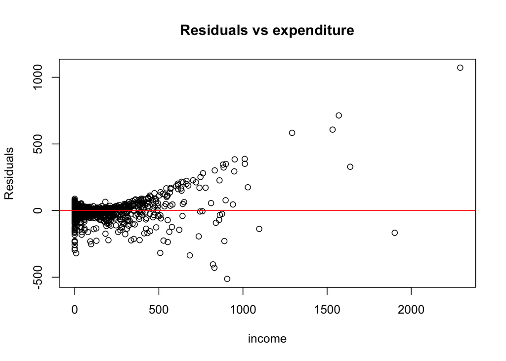

```r
res <- residuals(model1)

# expenditure
plot(train_data$expenditure, res,
     xlab = "income",
     ylab = "Residuals",
     main = "Residuals vs expenditure")
abline(h = 0, col = "red")
```

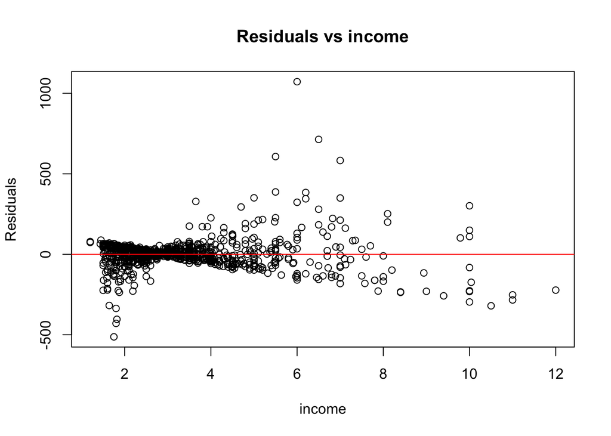

```r
# income
plot(train_data$income, res,
     xlab = "income",
     ylab = "Residuals",
     main = "Residuals vs income")
abline(h = 0, col = "red")
```

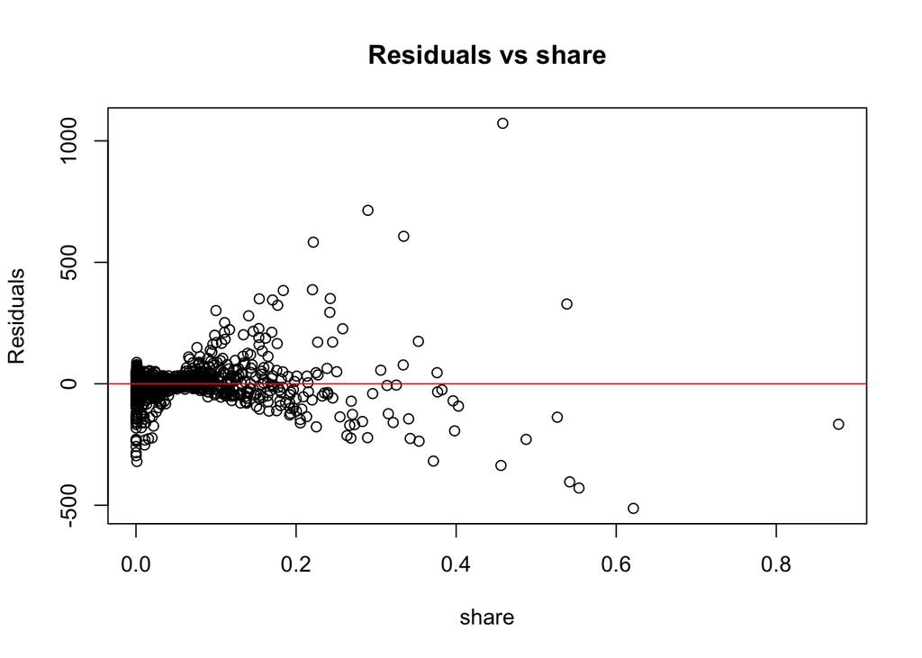

```r
# share
plot(train_data$share, res,
     xlab = "share",
     ylab = "Residuals",
     main = "Residuals vs share")
abline(h = 0, col = "red")
```

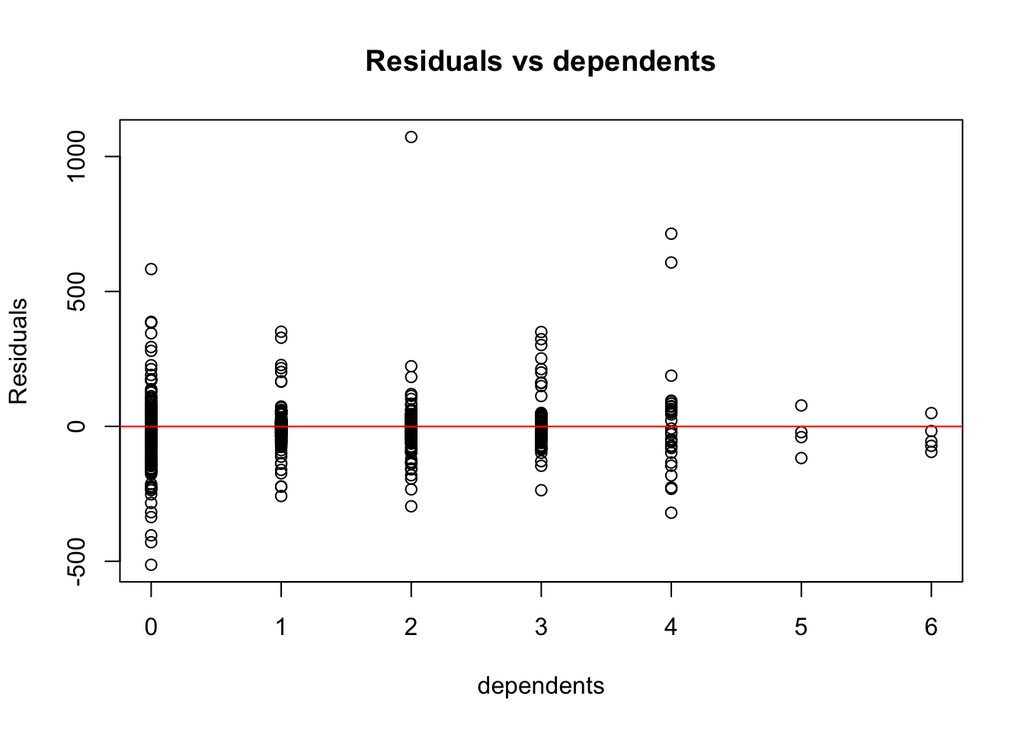

```r
# dependents
plot(train_data$dependents, res,
     xlab = "dependents",
     ylab = "Residuals",
     main = "Residuals vs dependents")
abline(h = 0, col = "red")
```

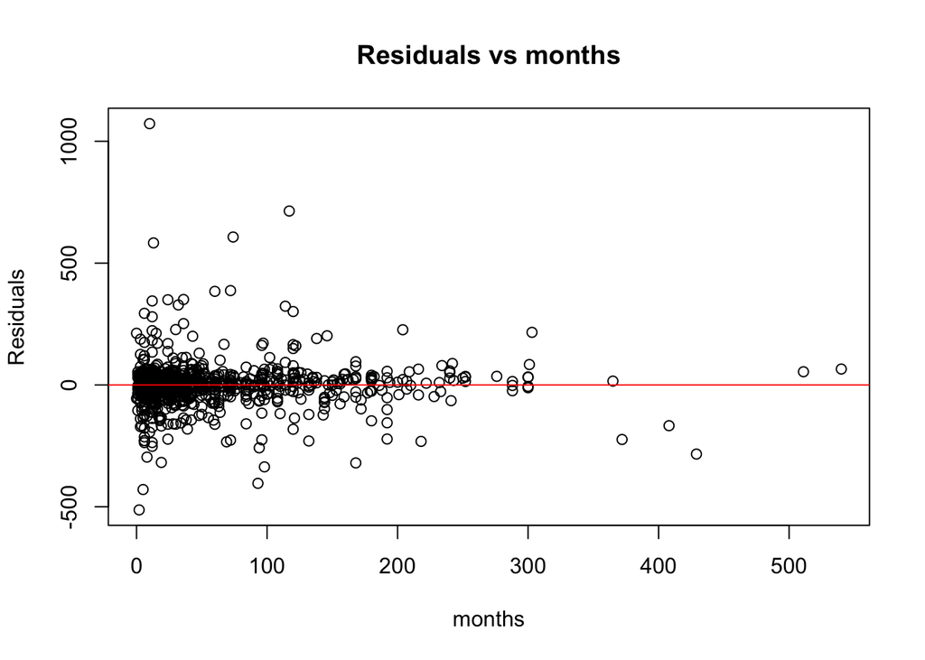

```r
# months
plot(train_data$months, res,
     xlab = "months",
     ylab = "Residuals",
     main = "Residuals vs months")
abline(h = 0, col = "red")
```

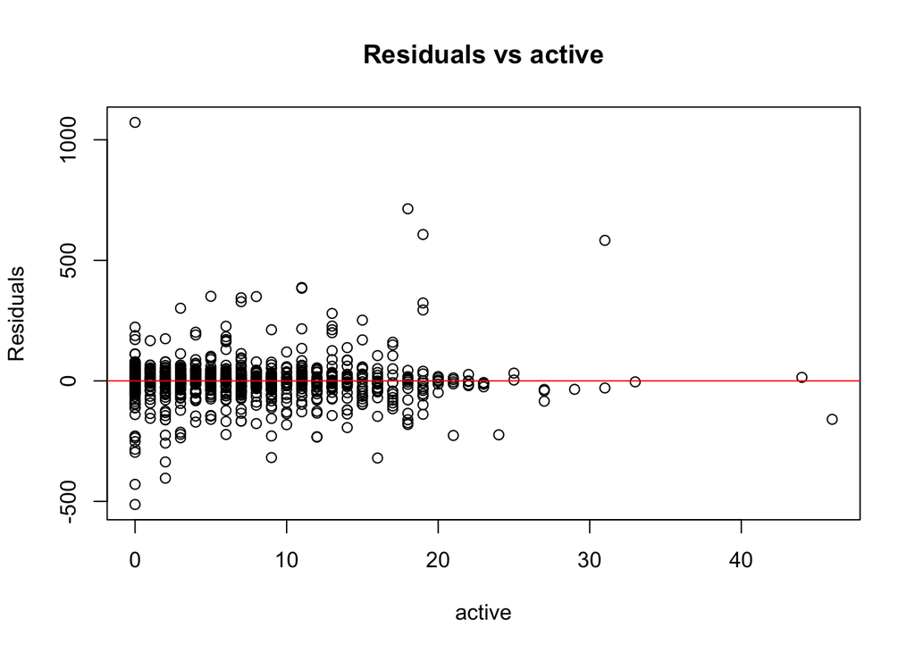

```r
# active
plot(train_data$active, res,
     xlab = "active",
     ylab = "Residuals",
     main = "Residuals vs active")
abline(h = 0, col = "red")
```

From the performance of residual plots, there are curvature existed in the variable income, share, and month.

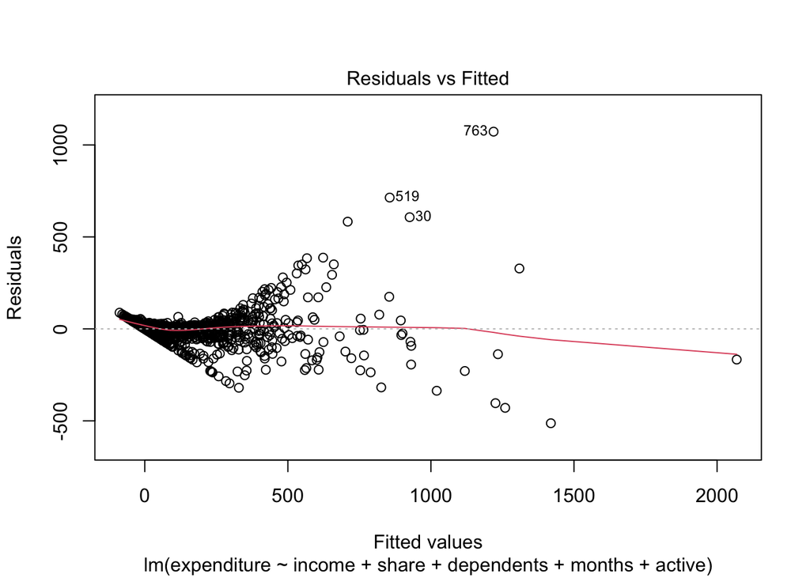

```r
# create a reusable function to plot residual vs fitted plot
plot_diagnostics <- function(model, title = NULL) {
  res <- residuals(model)
  fit <- fitted(model)

  # Residuals vs Fitted
  plot(fit, res,
       xlab = "Fitted Values",
       ylab = "Residuals",
       main = ifelse(is.null(title),
                     "Residuals vs Fitted",
                     paste(title, "- Residuals vs Fitted")))
  abline(h = 0, col = "red", lwd = 2)

  # Q-Q Plot
  qqnorm(res,
         main = ifelse(is.null(title),
                       "Normal Q-Q Plot",
                       paste(title, "- Q-Q Plot")))
  qqline(res, col = "red", lwd = 2)
}

plot(model1, which=1) # residuals vs fitted
```

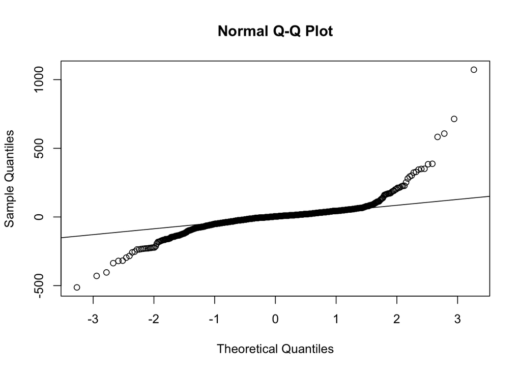

```r
qqnorm(resid(model1)); qqline(resid(model1)) # normality
```

```r
# the residual scatter plot shows a cone shape with high variance. This means that the residuals exponentially increases as the values increase. There is also a broad trend curve exists. A transformation is required.
```

```r
# Polynomial terms
train_data$months_c    <- train_data$months - mean(train_data$months)
train_data$months_c2   <- train_data$months_c^2

train_data$income2 <- train_data$income^2
train_data$share2  <- train_data$share^2
train_data$months2 <- train_data$months^2
```

```r
# income + share
model2 <- lm(expenditure ~ income + income2 + share  + share2  + months + dependents + active, data = train_data)
summary(model2)
```

```
##
## Call:
## lm(formula = expenditure ~ income + income2 + share + share2 +
##     months + dependents + active, data = train_data)
##
## Residuals:
##     Min      1Q  Median      3Q     Max
## -351.46  -36.67   -4.28   30.25 1091.68
##
## Coefficients:
##              Estimate Std. Error t value Pr(>|t|)
## (Intercept) -228.8530    14.5803 -15.696  < 2e-16 ***
## income        88.1860     6.8354  12.901  < 2e-16 ***
## income2       -4.7251     0.6604  -7.155 1.71e-12 ***
## share       2740.3686    64.5730  42.438  < 2e-16 ***
## share2      -921.9591   140.9000  -6.543 1.00e-10 ***
## months        -0.1040     0.0454  -2.291   0.0222 *
## dependents     4.1192     2.6248   1.569   0.1169
## active         0.4368     0.4869   0.897   0.3699
## ---
## Signif. codes:  0 '***' 0.001 '**' 0.01 '*' 0.05 '.' 0.1 ' ' 1
##
## Residual standard error: 91.35 on 915 degrees of freedom
## Multiple R-squared:  0.8558, Adjusted R-squared:  0.8547
## F-statistic: 775.6 on 7 and 915 DF,  p-value: < 2.2e-16
```

```r
# adj r^2: 0.8547

# all quadratic terms
model3 <- lm(expenditure ~ income + income2 + share  + share2  + months + months2 + dependents + active, data = train_data)
summary(model3)
```

```
##
## Call:
## lm(formula = expenditure ~ income + income2 + share + share2 +
##     months + months2 + dependents + active, data = train_data)
##
## Residuals:
##     Min      1Q  Median      3Q     Max
## -350.81  -36.44   -4.13   30.53 1092.57
##
## Coefficients:
##               Estimate Std. Error t value Pr(>|t|)
## (Intercept) -2.295e+02  1.464e+01 -15.681  < 2e-16 ***
## income       8.794e+01  6.852e+00  12.833  < 2e-16 ***
## income2     -4.698e+00  6.625e-01  -7.091 2.66e-12 ***
## share        2.740e+03  6.460e+01  42.421  < 2e-16 ***
## share2      -9.211e+02  1.410e+02  -6.535 1.06e-10 ***
## months      -5.487e-02  9.932e-02  -0.552    0.581
## months2     -1.757e-04  3.158e-04  -0.556    0.578
## dependents   3.955e+00  2.642e+00   1.497    0.135
## active       4.201e-01  4.880e-01   0.861    0.390
## ---
## Signif. codes:  0 '***' 0.001 '**' 0.01 '*' 0.05 '.' 0.1 ' ' 1
##
## Residual standard error: 91.39 on 914 degrees of freedom
## Multiple R-squared:  0.8558, Adjusted R-squared:  0.8546
## F-statistic: 678.2 on 8 and 914 DF,  p-value: < 2.2e-16
```

```r
# adj r^2: 0.8546

# transformation
# model4 <- lm(expenditure ~ log_income + log_share + dependents + months_c + months_c2 + active, data = train_data)
# summary(model4)
# # adj r^2: 0.8523
#
# # all sqrt (including polynomial months on sqrt scale)
# model5 <- lm(expenditure ~ log_income + log_share + dependents + sqrt_months_c + sqrt_months_c2 + active, data = train_data)
# summary(model5)
# # adj r^2: 0.8524
```

```r
# compare the adjusted R^2 for the models that performed better
cat("Adjusted R^2: \nModel 1: ", summary(model1)$adj.r.squared, "\nModel 2: ", summary(model2)$adj.r.squared,
    "\nModel 3: ", summary(model3)$adj.r.squared)
```

```
## Adjusted R^2:
## Model 1:  0.8394792
## Model 2:  0.8546664
## Model 3:  0.8545566
```

```r
# compare the VIF for multicollinearity
cat("\nVIF: \nModel 1: ")
```

```
##
## VIF:
## Model 1:
```

```r
print(vif(model1), type = "predictor")
```

```
##     income      share dependents     months     active
##   1.180984   1.015459   1.148239   1.036684   1.034308
```

```r
cat ("\nModel 2: ")
```

```
##
## Model 2:
```

```r
print(vif(model2), type = "predictor")
```

```
##     income    income2      share     share2     months dependents     active
##  14.660940  14.031714   3.782285   3.770604   1.036922   1.169552   1.041060
```

```r
cat("\nModel 3: ")
```

```
##
## Model 3:
```

```r
print(vif(model3), type = "predictor")
```

```
##     income    income2      share     share2     months    months2 dependents
##  14.723042  14.109987   3.782295   3.771032   4.959193   4.889934   1.184302
##     active
##   1.045025
```

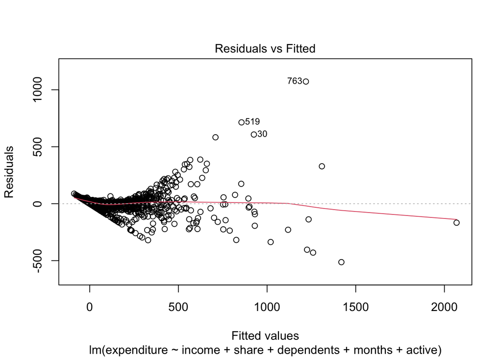

```r
# residual plot
plot(model1, which=1) # residuals vs fitted
```

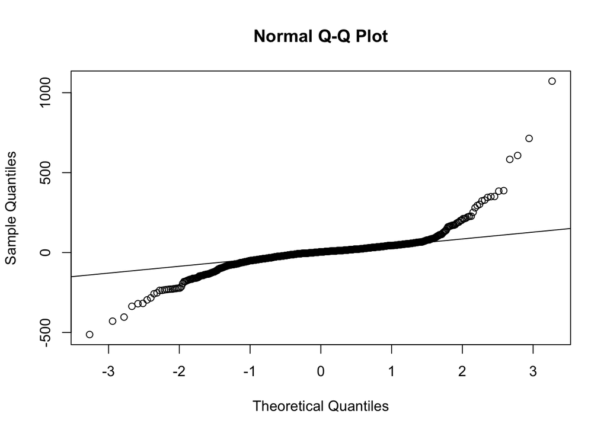

```r
qqnorm(resid(model1)); qqline(resid(model1)) # normality
```

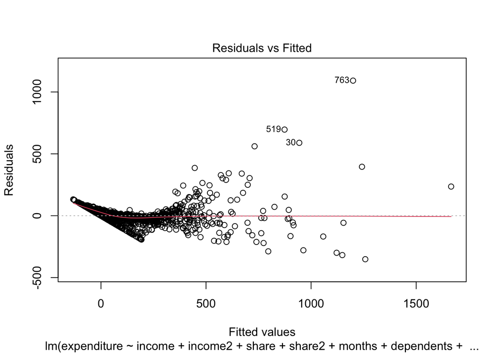

```r
plot(model2, which=1) # residuals vs fitted
```

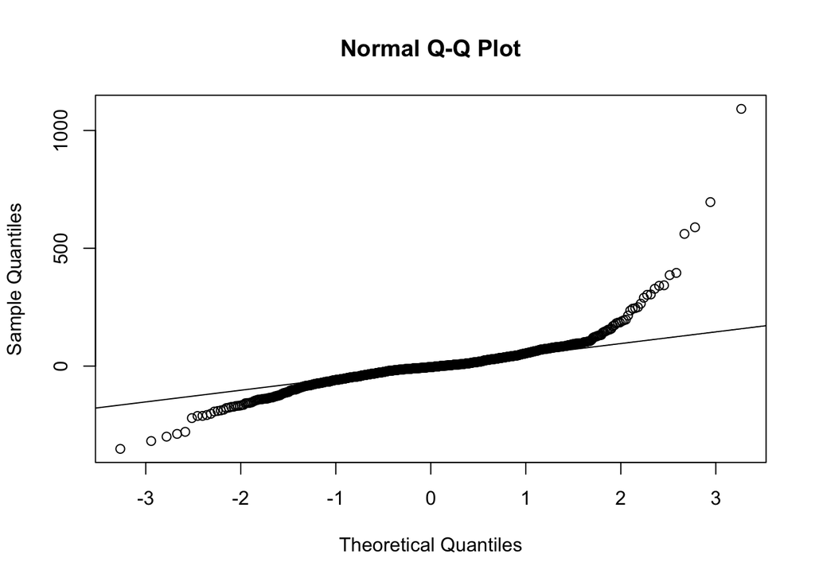

```r
qqnorm(resid(model2)); qqline(resid(model2)) # normality
```

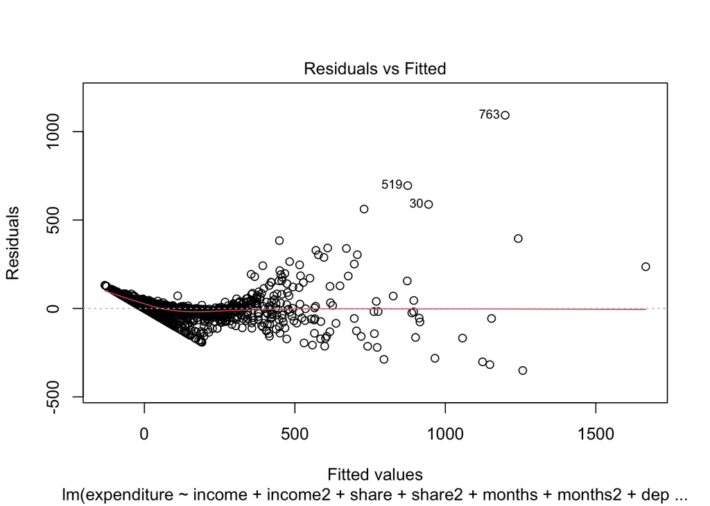

```r
plot(model3, which=1) # residuals vs fitted
```

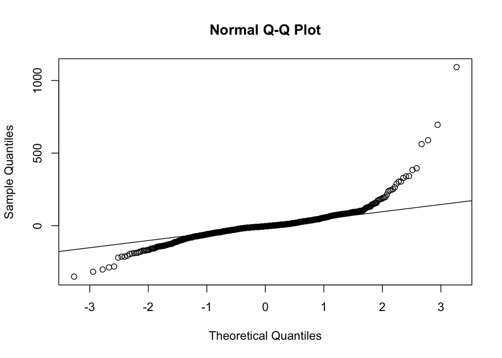

```r
qqnorm(resid(model3)); qqline(resid(model3)) # normality
```

After checking for curvature in the predictors, we found evidence of nonlinear patterns in income, share, and months, so we explored adding quadratic terms instead of applying transformations at this stage. Among all fitted curvature models, the two best-performing ones were: (1) the model including quadratic terms for income and share, and (2) the model including quadratic terms for income, share, and months. Although the residual-versus-fitted and Q–Q plots did not show substantial visual improvement over the baseline model (only a little bit), these two models achieved the highest adjusted R^2 values among all curvature combinations and surpassed the baseline model (model 1). Therefore, these two curvature-enhanced models are retained for further consideration in the next modeling stage.

# **Step 3 — Explore Interaction Terms (Individual Work)**

Each member is focusing on different predictors, and I was assigned to explore more about the potentials of variable $months$.

```r
#fit model with different combination of interaction with months
model4 <- lm(expenditure ~ income + share + dependents * months + active, data = train_data)
model5 <- lm(expenditure ~ income + share * months + dependents + active, data = train_data)
model6 <- lm(expenditure ~ income * months + share + dependents + active, data = train_data)
model7 <- lm(expenditure ~ income + share + dependents + active * months, data = train_data)

cat("Adjusted R^2: \nModel 4: ", summary(model4)$adj.r.squared,
    "\nModel 5: ", summary(model5)$adj.r.squared,
    "\nModel 6: ", summary(model6)$adj.r.squared,
    "\nModel 7: ", summary(model7)$adj.r.squared)
```

```
## Adjusted R^2:
## Model 4:  0.8394281
## Model 5:  0.8398366
## Model 6:  0.8412528
## Model 7:  0.8393493
```

```r
# Use F test to see whether the interaction term is statistically significant
anova(model1, model4)
```

```
## Analysis of Variance Table
##
## Model 1: expenditure ~ income + share + dependents + months + active
## Model 2: expenditure ~ income + share + dependents * months + active
##   Res.Df     RSS Df Sum of Sq      F Pr(>F)
## 1    917 8452561
## 2    916 8446032  1    6529.8 0.7082 0.4003
```

```r
anova(model1, model5)
```

```
## Analysis of Variance Table
##
## Model 1: expenditure ~ income + share + dependents + months + active
## Model 2: expenditure ~ income + share * months + dependents + active
##   Res.Df     RSS Df Sum of Sq      F  Pr(>F)
## 1    917 8452561
## 2    916 8424545  1     28016 3.0462 0.08126 .
## ---
## Signif. codes:  0 '***' 0.001 '**' 0.01 '*' 0.05 '.' 0.1 ' ' 1
```

```r
anova(model1, model6)
```

```
## Analysis of Variance Table
##
## Model 1: expenditure ~ income + share + dependents + months + active
## Model 2: expenditure ~ income * months + share + dependents + active
##   Res.Df     RSS Df Sum of Sq      F   Pr(>F)
## 1    917 8452561
## 2    916 8350052  1    102509 11.245 0.000831 ***
## ---
## Signif. codes:  0 '***' 0.001 '**' 0.01 '*' 0.05 '.' 0.1 ' ' 1
```

```r
anova(model1, model7)
```

```
## Analysis of Variance Table
##
## Model 1: expenditure ~ income + share + dependents + months + active
## Model 2: expenditure ~ income + share + dependents + active * months
##   Res.Df     RSS Df Sum of Sq      F Pr(>F)
## 1    917 8452561
## 2    916 8450173  1    2388.3 0.2589  0.611
```

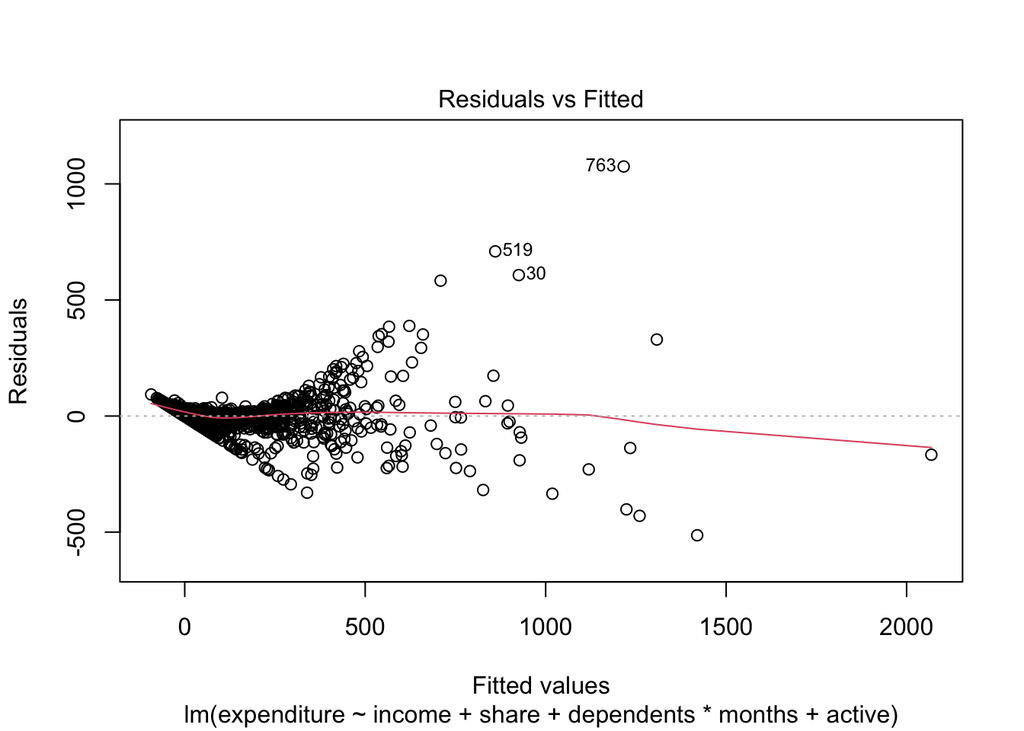

```r
# plot the residual vs fitted model and qq plot to see any improvements
plot(model4, which=1) # residuals vs fitted
```

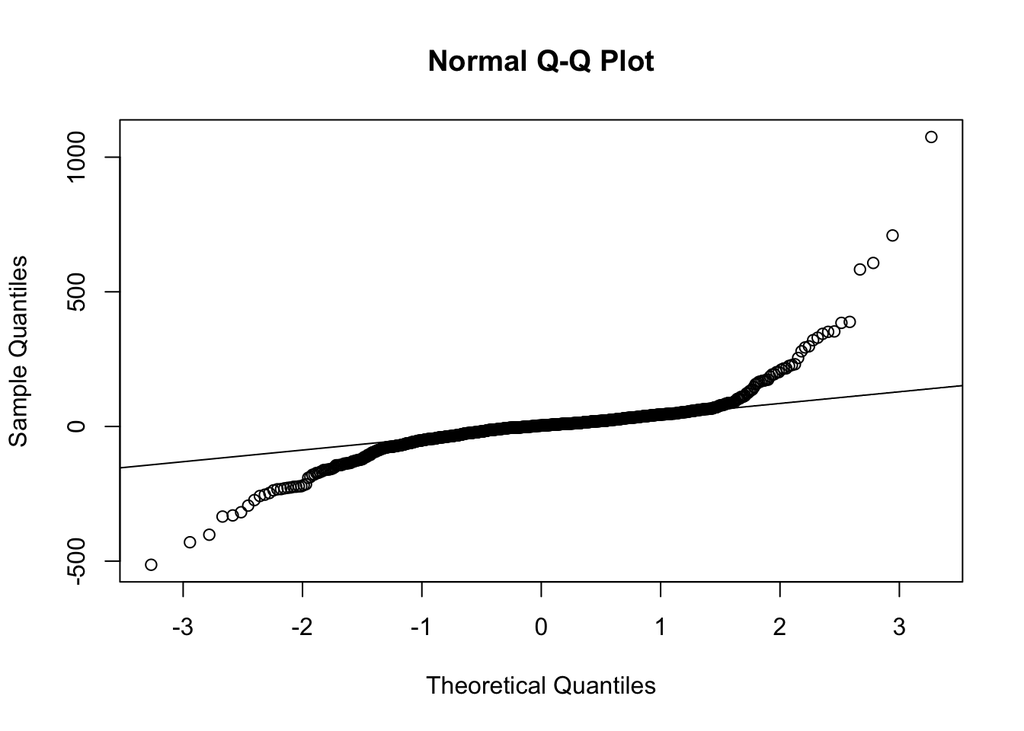

```r
qqnorm(resid(model4)); qqline(resid(model4)) # normality
```

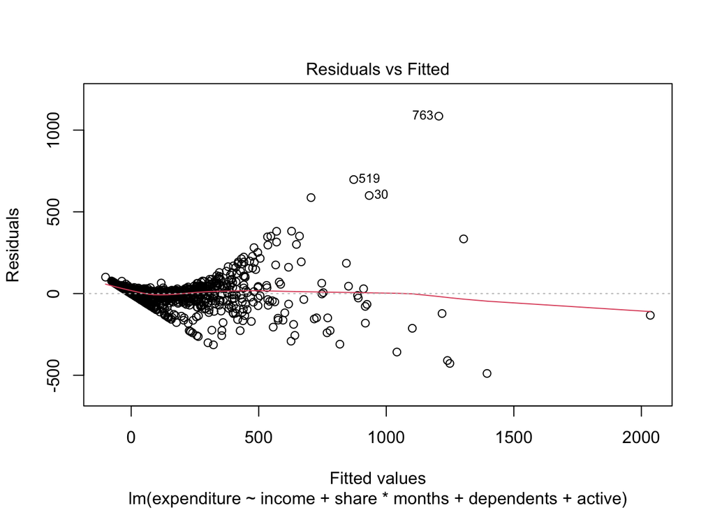

```r
plot(model5, which=1) # residuals vs fitted
```

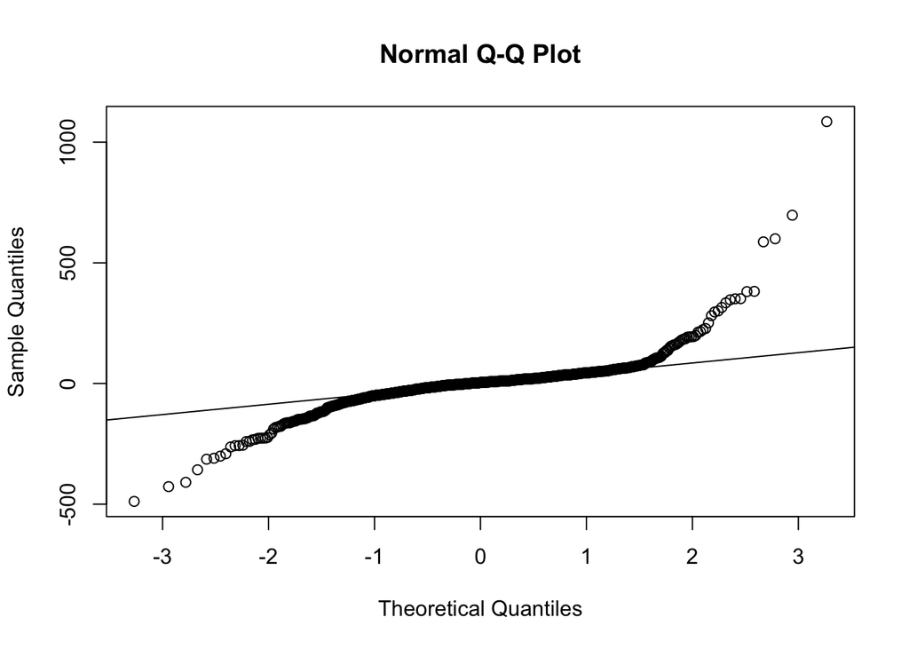

```r
qqnorm(resid(model5)); qqline(resid(model5)) # normality
```

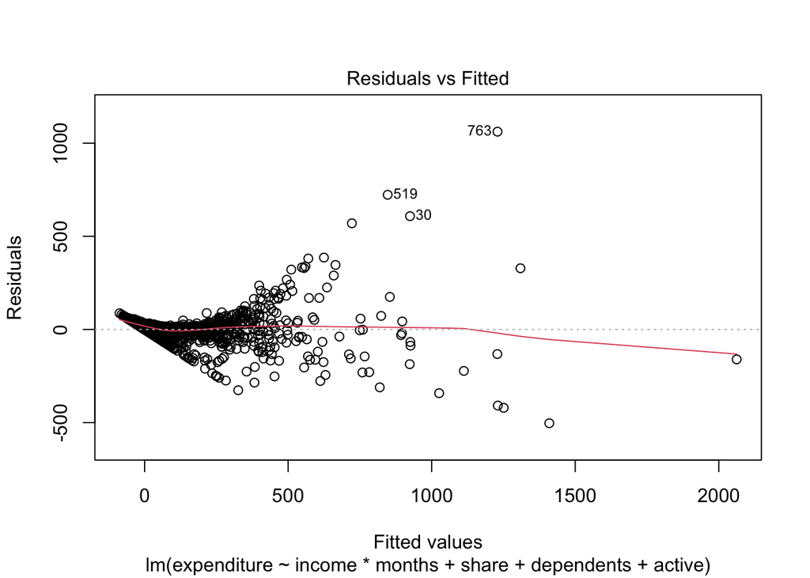

```r
plot(model6, which=1) # residuals vs fitted
```